# Homework 1

### Problem 1: Qualitative predictors

> The Season variable is an example of what’s called a *qualitative* or *categorical* predictor. In R, such variables are called `factors`. This problems gets to fit a model with a qualitative predictor and to interpret the findings.

##### **(a)** Suppose we were interested in predicting the count of total bike rentals by using the *season* as the predictor. Fit a linear (using the lm command) regression model with `cnt` as the response and `season` as the input. Use the `tidy()` and `kable()` commands to produce a nice looking coefficients table.

(Maybe look at https://rstudio-pubs-static.s3.amazonaws.com/58870_136d938b1ffd427ab5b30a98b663b127.html for an idea)

```r
lm_bikes = lm(cnt~season, data = bikes) # Create the linear regression
summary(lm_bikes) # Review the linear regression
```

```
##
## Call:
## lm(formula = cnt ~ season, data = bikes)
##
## Residuals:
##     Min      1Q  Median      3Q     Max
## -4706.2 -1065.6  -181.3  1219.2  5231.9
##
## Coefficients:
##              Estimate Std. Error t value Pr(>|t|)
## (Intercept)    2604.1      116.6   22.33   <2e-16 ***
## seasonSpring   2388.2      164.2   14.54   <2e-16 ***
## seasonSummer   3040.2      163.4   18.61   <2e-16 ***
## seasonFall     2124.0      165.6   12.83   <2e-16 ***
## ---
## Signif. codes:  0 '***' 0.001 '**' 0.01 '*' 0.05 '.' 0.1 ' ' 1
##
## Residual standard error: 1569 on 727 degrees of freedom
## Multiple R-squared:  0.347,  Adjusted R-squared:  0.3443
## F-statistic: 128.8 on 3 and 727 DF,  p-value: < 2.2e-16
```

```r
tidy(lm_bikes) # Create a tidied coefficients table
```

```
## # A tibble: 4 × 5
##   term         estimate std.error statistic  p.value
##   <chr>           <dbl>     <dbl>     <dbl>    <dbl>
## 1 (Intercept)     2604.      117.      22.3 1.55e-84
## 2 seasonSpring    2388.      164.      14.5 3.04e-42
## 3 seasonSummer    3040.      163.      18.6 1.60e-63
## 4 seasonFall      2124.      166.      12.8 4.24e-34
```

##### **(b)** How many total coefficients are there in the model?

- There are 4 total coefficients in the model.

##### **(d)** Interpret the coefficients of `season` in the model.

The following is the average count of total bike rentals across the different seasons: In Winter (the intercept point), there is an average of 2604.1 bike rentals. In Spring, there is an average of 4992.3 bike rentals (2604.1+2388.2). In Summer, there is an average of 5644.3 bike rentals (2604.1+3040.2). In Fall, there is an average of 4,728.1 bike rentals (2604.1+2124.0). The p values for all of the coefficients are significantly less than 0.05, which suggests that there is statistical evidence of a difference in bike rental count depending on the season.

**Hint**: If you have not previously studied how to interpret qualitative variables in regressions, perhaps search on key terms ‘lm’, ‘r’, ‘categorical predictor’ ‘interpreting’.

### Problem 2: Multiple linear regression

> In this problem we’ll practice fitting and interpreting the results of a multiple linear regression.

##### **(a)** Fit a regression model with `cnt` as the response and the following variables as inputs: `temp`, `atemp`, `mnth`, `hum`, `windspeed`. Produce a nice looking coefficients table.

```r
multiplelm_bikes = lm(cnt ~ temp + atemp + mnth + hum + windspeed, data = bikes) # Creating a multiple linear regression with the count of total bike rentals as the dependent variable and temperature, 'feels like' temp, month, humidity, and windspeed (weather conditions) as the independent variable
summary(multiplelm_bikes) # Review the multiple linear regression
```

```
##
## Call:
## lm(formula = cnt ~ temp + atemp + mnth + hum + windspeed, data = bikes)
##
## Residuals:
##     Min      1Q  Median      3Q     Max
## -4829.6  -992.7  -188.5  1089.4  3615.1
##
## Coefficients:
##             Estimate Std. Error t value     Pr(>|t|)
## (Intercept) 5057.781    342.624  14.762      < 2e-16 ***
## temp          45.387     47.414   0.957       0.3388
## atemp         72.014     38.138   1.888       0.0594 .
## mnth          95.040     15.742   6.037 0.0000000025 ***
## hum          -35.262      3.801  -9.277      < 2e-16 ***
## windspeed    -59.159     10.601  -5.580 0.0000000339 ***
## ---
## Signif. codes:  0 '***' 0.001 '**' 0.01 '*' 0.05 '.' 0.1 ' ' 1
##
## Residual standard error: 1389 on 725 degrees of freedom
## Multiple R-squared:  0.4895, Adjusted R-squared:  0.486
## F-statistic:   139 on 5 and 725 DF,  p-value: < 2.2e-16
```

```r
tidy(multiplelm_bikes) # Create a tidied coefficients tables
```

```
## # A tibble: 6 × 5
##   term        estimate std.error statistic  p.value
##   <chr>          <dbl>     <dbl>     <dbl>    <dbl>
## 1 (Intercept)   5058.     343.      14.8   2.60e-43
## 2 temp            45.4     47.4      0.957 3.39e- 1
## 3 atemp           72.0     38.1      1.89  5.94e- 2
## 4 mnth            95.0     15.7      6.04  2.50e- 9
## 5 hum            -35.3      3.80    -9.28  1.98e-19
## 6 windspeed      -59.2     10.6     -5.58  3.39e- 8
```

### Problem 3: Dealing with collinearity

> As you probably already know from your most recent regression class, *collinear* or *highly correlated* predictors can make interpreting regression coefficients problematic. In this problem you will try to diagnose and address collinearity issues in the data.

##### **(a)** Use the `pairs()` function on the set of variables used in **Problem 2** to check if any of the predictor variables are highly correlated with one another. Your pairs plot should have scatterplots above the diagonal, and correlations below the diagonal.

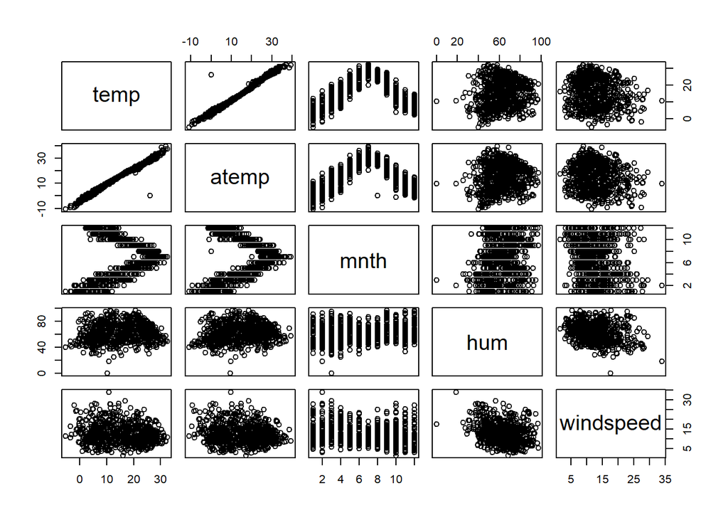

```r
colbikes = bikes %>%
select("temp", "atemp", "mnth", "hum", "windspeed") # Selecting the set of variables that were used in Problem 2
pairs(colbikes) # Using the pairs() function to see if any of the predictor variables are correlated to each other
```

```r
round(cor(colbikes),3) # Rounding the values in the correlation matrix
```

```
##             temp  atemp   mnth    hum windspeed
## temp       1.000  0.992  0.220  0.127    -0.158
## atemp      0.992  1.000  0.227  0.140    -0.184
## mnth       0.220  0.227  1.000  0.222    -0.208
## hum        0.127  0.140  0.222  1.000    -0.248
## windspeed -0.158 -0.184 -0.208 -0.248     1.000
```

Notes: Positive numbers = positive correlation and vice versa, closer the number between 1 or -1, the stronger the correlation

**Hint**: A complete example of how to use the `pairs()` command to construct such plots may be found here: [Pairs plot example](http://www.andrew.cmu.edu/user/achoulde/94842/lectures/lecture08/lecture08-94842.html#collinearity-and-pairs-plots)

##### **(b)** Are any of the predictors highly correlated? Are you surprised that these predictors are highly correlated, or can you think of a reason for why it makes sense that they should be correlated?

- The ‘temp’ and ‘atemp’ predictors are highly correlated with correlation values of 0.992. I am not surprised that these predictors are highly correlated because these variables both relate to temperature and have similar values. Generally, the actual and “feels-like” temperature only differ by a few degrees. The ‘atemp’ typically takes into account the humidity as well.

##### **(c)** Refit your regression model, but this time **omit** the `temp` variable. Display the coefficients table for this model.

```r
multiplelm_bikes2 = lm(cnt ~ atemp + mnth + hum + windspeed, data = bikes) # Creating a multiple linear regression with the count of total bike rentals as the dependent variable and temperature, 'feels like' temp, month, humidity, and windspeed (weather conditions) as the independent variable
summary(multiplelm_bikes2) # Review the multiple linear regression
```

```
##
## Call:
## lm(formula = cnt ~ atemp + mnth + hum + windspeed, data = bikes)
##
## Residuals:
##     Min      1Q  Median      3Q     Max
## -4864.6  -993.4  -171.3  1102.3  4114.5
##
## Coefficients:
##             Estimate Std. Error t value Pr(>|t|)
## (Intercept) 5186.624    315.061  16.462  < 2e-16 ***
## atemp        108.210      4.970  21.774  < 2e-16 ***
## mnth          95.016     15.741   6.036 2.51e-09 ***
## hum          -35.446      3.796  -9.338  < 2e-16 ***
## windspeed    -57.397     10.440  -5.498 5.33e-08 ***
## ---
## Signif. codes:  0 '***' 0.001 '**' 0.01 '*' 0.05 '.' 0.1 ' ' 1
##
## Residual standard error: 1389 on 726 degrees of freedom
## Multiple R-squared:  0.4889, Adjusted R-squared:  0.486
## F-statistic: 173.6 on 4 and 726 DF,  p-value: < 2.2e-16
```

```r
tidy(multiplelm_bikes2) # Create a tidied coefficients tables
```

```
## # A tibble: 5 × 5
##   term        estimate std.error statistic  p.value
##   <chr>          <dbl>     <dbl>     <dbl>    <dbl>
## 1 (Intercept)   5187.     315.       16.5  5.56e-52
## 2 atemp          108.       4.97     21.8  2.74e-81
## 3 mnth            95.0     15.7       6.04 2.51e- 9
## 4 hum            -35.4      3.80     -9.34 1.18e-19
## 5 windspeed      -57.4     10.4      -5.50 5.33e- 8
```

### Investigating Collinearity Without the ‘Temp’ Term

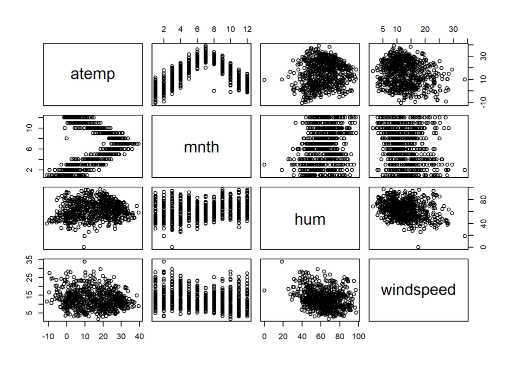

```r
colbikes2 = bikes %>%
select("atemp", "mnth", "hum", "windspeed") # Selecting the set of variables that were used in Problem 2
pairs(colbikes2) # Using the pairs() function to see if any of the predictor variables are correlated to each other
```

```r
round(cor(colbikes2), 3) # Rounding the values in the correlation matrix
```

```
##            atemp   mnth    hum windspeed
## atemp      1.000  0.227  0.140    -0.184
## mnth       0.227  1.000  0.222    -0.208
## hum        0.140  0.222  1.000    -0.248
## windspeed -0.184 -0.208 -0.248     1.000
```

##### **(d)** What is the coefficient of `atemp` in this new model? Is it very different from the `atemp` coefficient estimated in part **(b)**? Is it statistically significant? Explain your findings.

# Optional Material Below

### Problem 4: Exploring non-linearities

> **Hint**: For this problem, you will find it useful to know about the `jitter` feature in graphics. [Begin by reviewing the code at this link](http://www.andrew.cmu.edu/user/achoulde/94842/misc/extra_tips.html#jittering-points), and be sure to use what you feel to be an appropriate amount of jitter in your plots for **(a)**, **(b)** and **(c)**. You **should not** use jitter for parts **(d)** onward.

##### **(a)** Using `ggplot2` graphics, construct a scatterplot of `cnt` (bikeshare count) across `mnth` (month of the year). Describe what you see. Does a linear relationship appear to be a good way of modeling how bikeshare count varies with month?

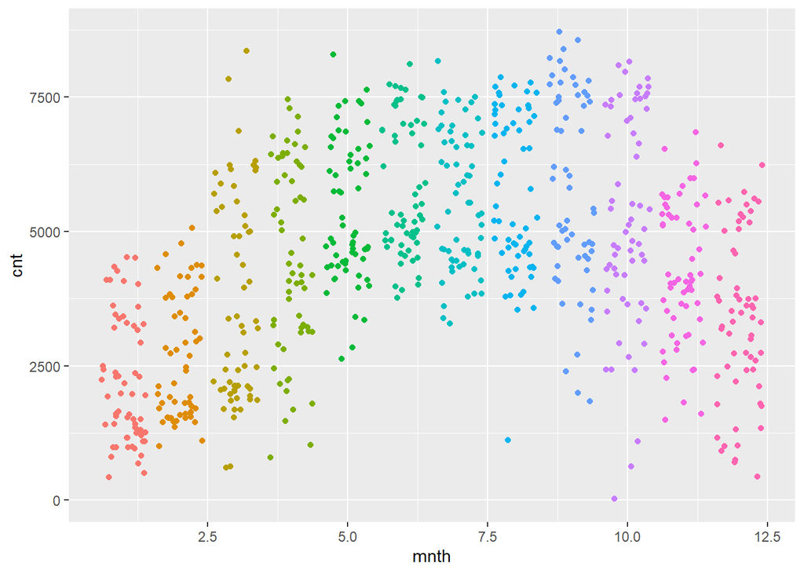

```r
bikes_optional = bikes %>%
  select(cnt, mnth)
  ggplot(data = bikes, aes(x = mnth, y = cnt, color = as.factor(mnth))) + geom_jitter() + guides(color = "none")
```

- In the scatterplot, the total count of bike rentals is plotted for the number of days in each month. The cnt variable increases during the Spring and Summer months in particular and decreases during the Winter months. Since not all of the data points follow a clear straight progression, it would not be useful to use a linear relationship to model the difference in bikeshare counts per month.

##### **(b)** Use `ggplot2`’s `stat_smooth()` overlays to try out *different degree polynomial fits* for modeling the relationship between `cnt` and `month`. Display the lowest degree polynomial fit that appears to nicely capture the trends in the data. Explain your choice.

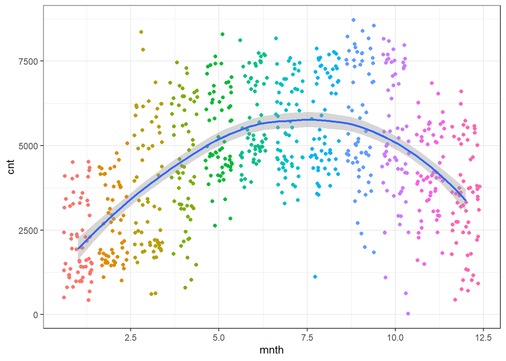

```r
library ("ggplot2")

# First try using stat_smooth using the example. With this try, the regression line does not change when I change the degree of the polynomial.
bikes_optional = bikes %>%
  select(cnt, mnth)
  ggplot(data = bikes, aes(x = mnth, y = cnt, color = as.factor(mnth))) + geom_jitter() + guides(color = FALSE) +
    stat_smooth(aes(group = 2))+
    theme_bw()
```

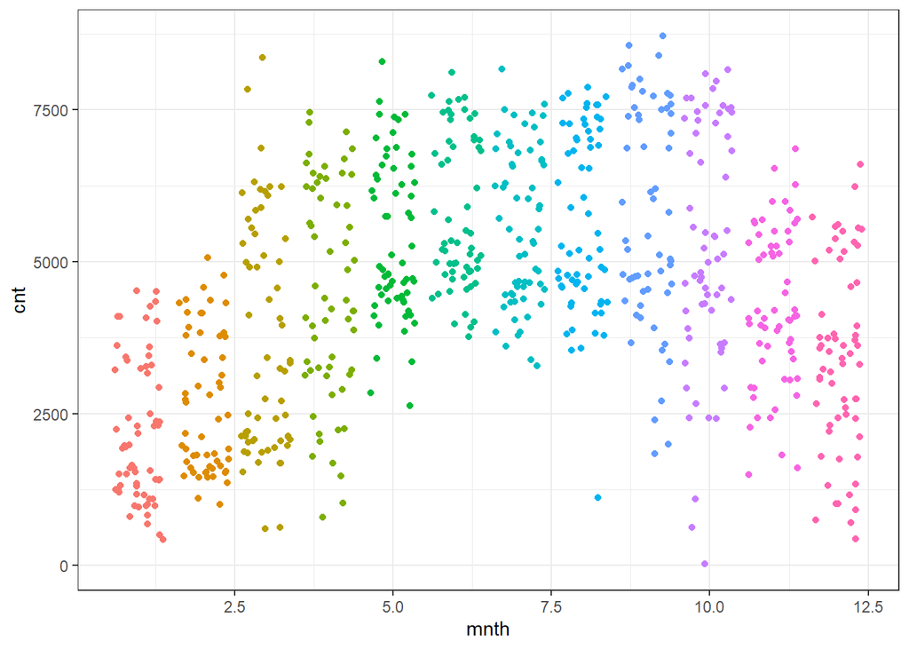

```r
# Second attempt on using stat_smooth
bikes_optional <- bikes %>%
  select(cnt, mnth)
  ggplot(data = bikes, aes(x = mnth, y = cnt, color = as.factor(mnth))) + geom_jitter() + guides(color = FALSE) +
  stat_smooth(method = "lm",
              formula = cnt ~ poly(mnth,1)) +
  theme_bw()
```

```r
polybikes = lm(cnt~poly(mnth,2), data = bikes)
summary(polybikes)
```

```
##
## Call:
## lm(formula = cnt ~ poly(mnth, 2), data = bikes)
##
## Residuals:
##     Min      1Q  Median      3Q     Max
## -4998.1 -1118.4  -260.9  1315.0  4449.9
##
## Coefficients:
##                 Estimate Std. Error t value Pr(>|t|)
## (Intercept)      4504.35      56.57   79.62   <2e-16 ***
## poly(mnth, 2)1  14654.16    1529.59    9.58   <2e-16 ***
## poly(mnth, 2)2 -28662.19    1529.59  -18.74   <2e-16 ***
## ---
## Signif. codes:  0 '***' 0.001 '**' 0.01 '*' 0.05 '.' 0.1 ' ' 1
##
## Residual standard error: 1530 on 728 degrees of freedom
## Multiple R-squared:  0.3783, Adjusted R-squared:  0.3766
## F-statistic: 221.5 on 2 and 728 DF,  p-value: < 2.2e-16
```

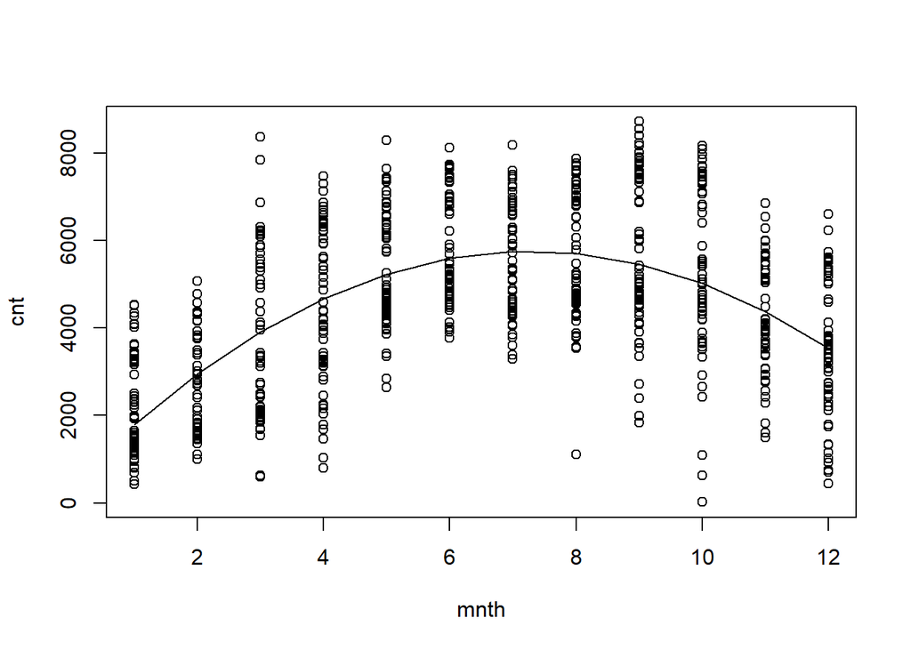

```
## integer(0)
```

```r
plot(cnt ~ mnth, bikes) +
lines(sort(bikes$mnth), fitted(polybikes)[order(bikes$mnth)], color = "blue", type = "l")
```

```r
polybikes10 = lm(cnt~poly(mnth,10), data = bikes)
summary(polybikes)
```

```
##
## Call:
## lm(formula = cnt ~ poly(mnth, 2), data = bikes)
##
## Residuals:
##     Min      1Q  Median      3Q     Max
## -4998.1 -1118.4  -260.9  1315.0  4449.9
##
## Coefficients:
##                 Estimate Std. Error t value Pr(>|t|)
## (Intercept)      4504.35      56.57   79.62   <2e-16 ***
## poly(mnth, 2)1  14654.16    1529.59    9.58   <2e-16 ***
## poly(mnth, 2)2 -28662.19    1529.59  -18.74   <2e-16 ***
## ---
## Signif. codes:  0 '***' 0.001 '**' 0.01 '*' 0.05 '.' 0.1 ' ' 1
##
## Residual standard error: 1530 on 728 degrees of freedom
## Multiple R-squared:  0.3783, Adjusted R-squared:  0.3766
## F-statistic: 221.5 on 2 and 728 DF,  p-value: < 2.2e-16
```

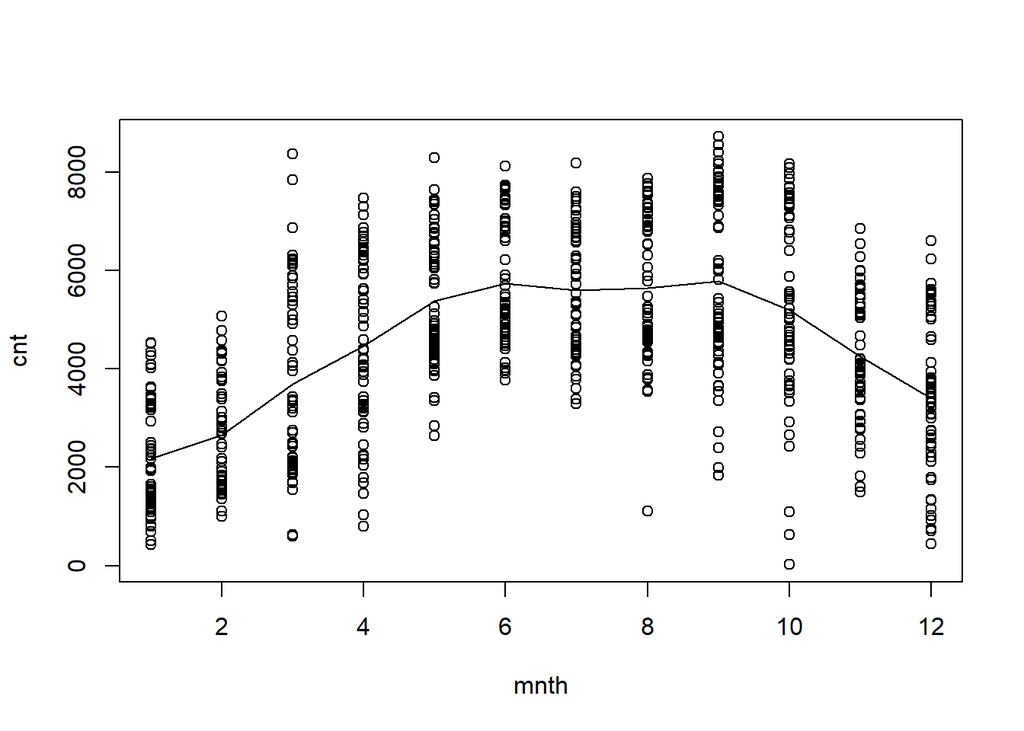

```
## integer(0)
```

```r
plot(cnt ~ mnth, bikes) +
lines(sort(bikes$mnth), fitted(polybikes10)[order(bikes$mnth)], color = "blue", type = "l")
```

```r
polybikes = lm(cnt ~ cut(mnth, breaks = c(-Inf,3,10,Inf)), data = bikes)
summary(polybikes)
```

```
##
## Call:
## lm(formula = cnt ~ cut(mnth, breaks = c(-Inf, 3, 10, Inf)), data = bikes)
##
## Residuals:
##    Min     1Q Median     3Q    Max
##  -5379  -1085   -221   1360   5516
##
## Coefficients:
##                                                  Estimate Std. Error t value
## (Intercept)                                        2846.4      118.2  24.084
## cut(mnth, breaks = c(-Inf, 3, 10, Inf))(3,10]      2554.5      141.0  18.120
## cut(mnth, breaks = c(-Inf, 3, 10, Inf))(10, Inf]    972.1      186.3   5.219
##                                                     Pr(>|t|)
## (Intercept)                                          < 2e-16 ***
## cut(mnth, breaks = c(-Inf, 3, 10, Inf))(3,10]        < 2e-16 ***
## cut(mnth, breaks = c(-Inf, 3, 10, Inf))(10, Inf] 0.000000234 ***
## ---
## Signif. codes:  0 '***' 0.001 '**' 0.01 '*' 0.05 '.' 0.1 ' ' 1
##
## Residual standard error: 1590 on 728 degrees of freedom
## Multiple R-squared:  0.3281, Adjusted R-squared:  0.3263
## F-statistic: 177.8 on 2 and 728 DF,  p-value: < 2.2e-16
```

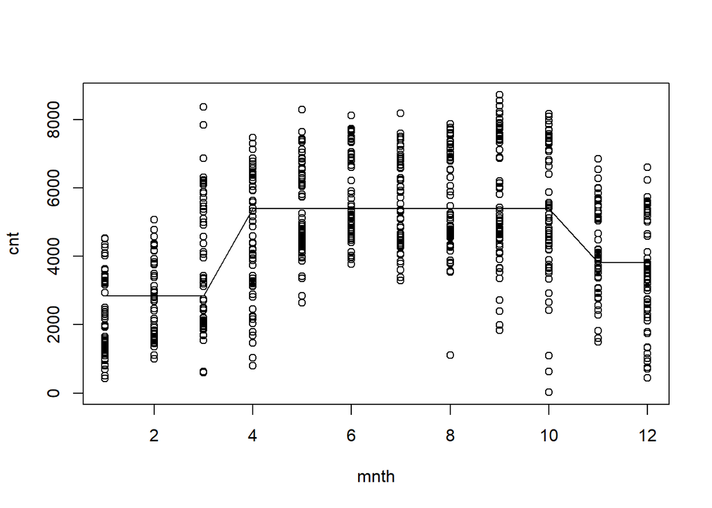

```
## integer(0)
```

```r
plot(cnt ~ mnth, bikes) +
lines(sort(bikes$mnth), fitted(polybikes)[order(bikes$mnth)], color = "blue", type = "l")
```

- The lowest degree polynomial fit that clearly captures the graph is 2. When increasing the degree of the polynomial after 2, the line changes to be not smooth and does not accurately captures or take into account all of the data points.

##### **(c)** Use `ggplot2`’s `stat_smooth()` overlays to try out *different step functions* for modeling the relationship between `cnt` and `month`. Display the model with the smallest number of “breaks” or “cuts” that nicely captures the trends in the data. Explain your choice.

You may want to look at

https://www.andrew.cmu.edu/user/achoulde/95791/lectures/code/week1.html

to get some options.

### The lines wont show when doing polynomial or stepwise function in ggplot

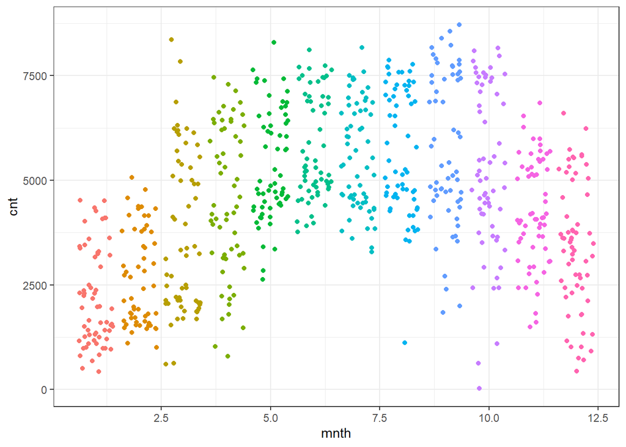

```r
bikes_optional = bikes %>%
  select("cnt", "mnth")
  qplot(data = bikes, x = mnth, y = cnt,  color = as.factor(mnth), geom = "jitter") +
    guides(color = FALSE) +
    stat_smooth(method = "lm", formula = cnt ~ cut(mnth, breaks = c(-Inf,3,10,Inf))) +
    theme_bw()
```

- Optional Material

##### Which do you think better describes the relationship between `cnt` and `mnth`: Polynomials, or Step Functions? Explain your answer.

- Optional Material

##### **(d)** Repeat parts **(a)** and **(b)** to determine appropriate degree polynomials for modeling the relationship between `cnt` and the other inputs: `atemp`, `hum` and `windspeed`. Summarize your choices. (Note: your polynomials can have different degrees for different inputs.)

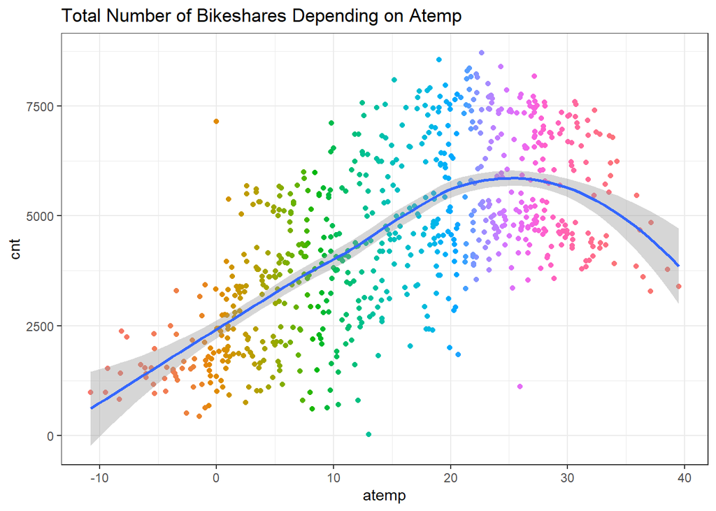

```r
bikes_optional = bikes %>%
   select(cnt, atemp, hum, windspeed)
  ggplot(data = bikes, aes(x = atemp, y = cnt, color = as.factor(atemp))) + geom_point() + guides(color = FALSE) +
    ggtitle("Total Number of Bikeshares Depending on Atemp") +
    geom_smooth(aes(group = 3)) +
    theme_bw()
```

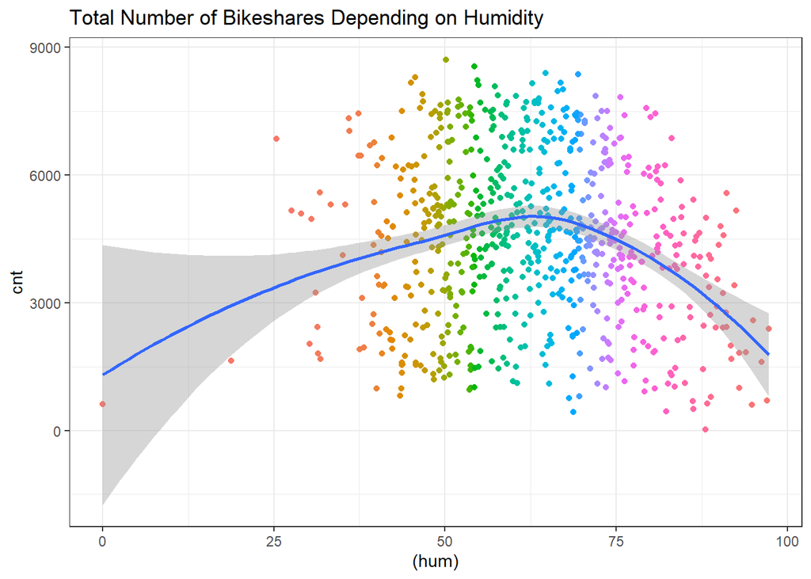

```r
  ggplot(data = bikes, aes(x = (hum), y = cnt, color = as.factor(hum))) + geom_point() + guides(color = FALSE) +
    ggtitle("Total Number of Bikeshares Depending on Humidity") +
    stat_smooth(aes(group = 8))+
    theme_bw()
```

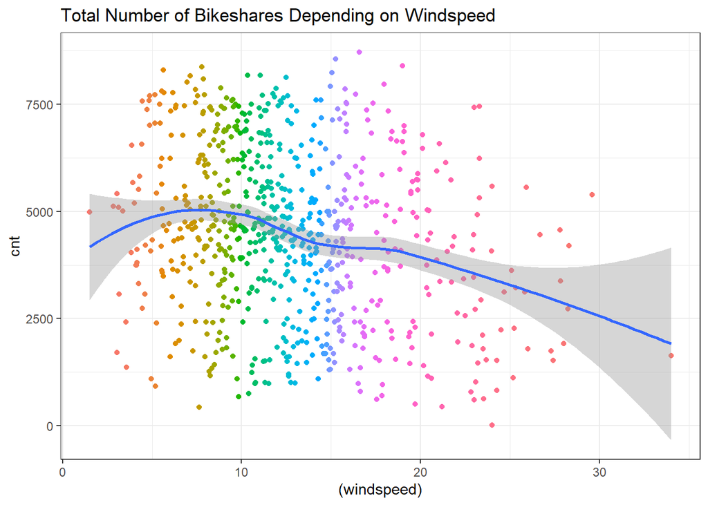

```r
 ggplot(data = bikes, aes(x = (windspeed), y = cnt, color = as.factor(windspeed))) + geom_point() + guides(color = FALSE) +
    ggtitle("Total Number of Bikeshares Depending on Windspeed") +
    stat_smooth(aes(group = 5))+
    theme_bw()
```

- Optional Material

##### **(e)** Use your answers to parts **(b)** and **(d)** to fit a polynomial regression model that regresses `cnt` on polynomials in the input variables: `atemp`, `mnth`, `hum`, and `windspeed`. How does the R-squared of this model compare to the R-squared of the model you fit in Problem 3(d)?

```r
# Optional Material
```

- Optional Material

##### **(f)** What is the total number of parameters in the model you fit in part **(e)**? How does this compare to the number of parameters in the model fit in Problem 3(d)?

- Optional Material